# CSIT 165 - Project2

Alex Yu and Audrey Lewis

12/19/2020

# Objective 1 - Global Trajectory

Your first task as a CSIT-165 data scientist is to determine the global trajectory of COVID-19 as far as confirmed, recovers, and deaths are concerned.

Create three overlapped scatter plots for the global trajectory of COVID-19 for confirmations, recoveries, and deaths. This required that the cases for each date are summed for all countries and provinces in the data set.

```r
#Sorting ConfirmedGlobal
confirmedGlobal_Sort <- confirmedGlobal %>% gather(key="date", value="confirmed", -c(`Country/Region`, `Province/State`, Lat, Long)) %>% group_by(`Country/Region`, date) %>% summarize(confirmed=sum(confirmed))
#Sorting DeathsGlobal
DeathsGlobal_Sort <- DeathsGlobal %>% gather(key="date", value="Deaths", -c(`Country/Region`, `Province/State`, Lat, Long)) %>% group_by(`Country/Region`, date) %>% summarize(Deaths=sum(Deaths))
#Sorting RecoveredGlobal
RecoveredGlobal_Sort <- RecoveredGlobal %>% gather(key="date", value="Recovered", -c(`Country/Region`, `Province/State`, Lat, Long)) %>% group_by(`Country/Region`, date) %>% summarize(Recovered=sum(Recovered))
#Combining Data to one
# Combined_Data <- full_join(confirmedGlobal_Sort, DeathsGlobal_Sort) %>% full_join(RecoveredGlobal_Sort) %>% group_by(`date`) %>% summarise_if(is.numeric, sum) %>% mutate(`date`=as.Date(`date`, format = "%m/%d/%y")) %>% gather(key=Type, value=Count, -`date`)

#Combining Data to one
Combined_Data <- full_join(confirmedGlobal_Sort, DeathsGlobal_Sort) %>% full_join(RecoveredGlobal_Sort) %>%

  # groups by date
  group_by(`date`)
```

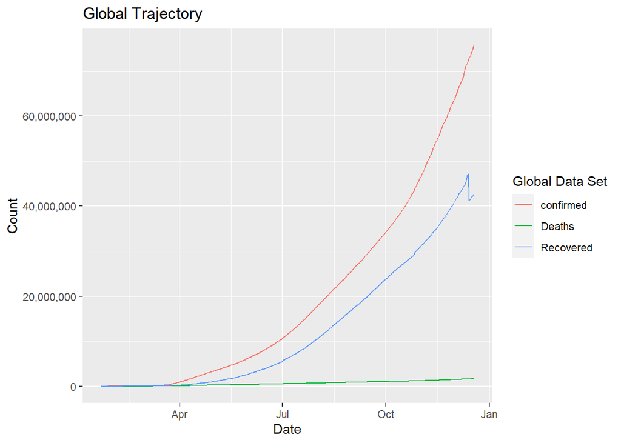

```r
  # totals all columns that are numeric
Combined_Data_Chart <- Combined_Data %>%
  summarise_if(is.numeric, sum) %>%

  # converts the date column into real dates for the chart
  mutate(`date`=as.Date(`date`, format = "%m/%d/%y")) %>%

  # gathers data into long form
  gather(key=Type, value=Count, -`date`)

ggplot(Combined_Data_Chart,
 aes(x = `date`, y = `Count`,
 group = `Type`)) +
 geom_line(aes(color=`Type`)) +
 scale_y_continuous(labels = scales::comma) +
 ggtitle("Global Trajectory") +
 labs(x = "Date", y = "Count", color = "Global Data Set")
```

The recent drop off in Recovered figures is due to an error with the Recovered data set. Corrected figures will be backfilled and updated as the data set errors are resolved.

# Objective 2 - Global Map

After realizing the vastness of the spread of COVID-19 from your global trajectory you are then asked to create a world map to gain an appreciation for where the most occurrences are.

Create this map using leaflet for the most recent date as shown below. Notice that hover labels show the province when the data is available and show the country when it is not. Also notice that the popup labels are customized to the data that is being clicked on. For extra help using leaflet, please consult this website along with the information provided in your textbooks.

```r
dfLatLongLookup <- DeathsGlobal %>%
  select(c(`Province/State`, `Country/Region`, `Lat`, `Long`))

dfMapData <- Combined_Data %>%
  filter(`date` == "12/18/20") %>%
  inner_join(dfLatLongLookup, by = "Country/Region")

leaflet(dfMapData) %>%
  addTiles() %>%
  addCircles(
    lng = ~Long, lat = ~Lat, weight = 1,
    radius = ~sqrt(confirmed)*100, popup = ~`Country/Region`,
    color = "blue", group = "Confirmed"
  ) %>%
  addCircles(
    lng = ~Long, lat = ~Lat, weight = 1,
    radius = ~sqrt(Deaths)*100, popup = ~`Country/Region`,
    color = "red", group = "Deaths"
  ) %>%
  addCircles(
    lng = ~Long, lat = ~Lat, weight = 1,
    radius = ~sqrt(Recovered)*100, popup = ~`Country/Region`,
    color = "green", group = "Recovered"
  ) %>%
  addLayersControl(
    overlayGroups = c("Confirmed", "Deaths", "Recovered")
  )
```

[interactive chart not shown]

# Objective 3 - Narrowing Down Hot Spots

Seeing the global map of COVID-19 cases results in the stark realization that some countries are more affected than others. In order to narrow down your studies, create a table using kable from knitr listing the top countries as far as confirmations, recoveries, and deaths. Now that we are using RMarkdown to create HTML files, we have much more options for how we display our table. For reference on how to customize tables using knitr, visit this website. Consult the table below for an example of a customized table ranking cases by country. While it is not required to replicate this table exactly, it would be a fantastic challenge to show off your knitr prowess.

```r
Combined_Data_Table <- Combined_Data %>%
  filter(`date` == "12/18/20") %>%

  # sorts table by confirmed cases, from highest to lowest
  arrange(desc(`confirmed`)) %>%

  # only shows top 10 results
  head(15)

Combined_Data_Table <- Combined_Data_Table %>%

  # removes the date column
  select(-(`date`))
#Creating table using kbl
kbl(Combined_Data_Table[2:5]) %>%
  kable_classic() %>%
add_header_above(c("", "confirmed" = 1, "Deaths" = 1, "Recovered" = 1))
```

| Country/Region | confirmed | Deaths | Recovered |
| --- | --- | --- | --- |
| US | 17459296 | 313588 | 0 |
| India | 10004599 | 145136 | 9550712 |
| Brazil | 7162978 | 185650 | 6322955 |
| Russia | 2764843 | 49170 | 2207398 |
| France | 2499529 | 60345 | 188488 |
| United Kingdom | 1982828 | 66640 | 4264 |
| Turkey | 1982090 | 17610 | 1753552 |
| Italy | 1921778 | 67894 | 1226086 |
| Spain | 1797236 | 48926 | 150376 |
| Argentina | 1531374 | 41672 | 1356755 |
| Germany | 1486839 | 25754 | 1095982 |
| Colombia | 1482072 | 40019 | 1354021 |
| Mexico | 1301546 | 117249 | 962397 |
| Poland | 1182864 | 24771 | 915576 |
| Iran | 1145651 | 53273 | 865474 |

# Objective 4 - Zooming Into California

```r
# creates new data frame for only CA confirmed cases
dfConfirmedCAChartData <- ConfirmedUS %>%

  # removes all columns with numeric values that aren't case counts
  select(-(`UID`)) %>%
  select(-(`code3`)) %>%
  select(-(`FIPS`)) %>%
  select(-(`Lat`)) %>%
  select(-(`Long_`)) %>%

  # retains only the California row
  filter(`Province_State` == "California") %>%

  # groups by State
  group_by(`Province_State`) %>%

  # totals all columns that are numeric
  summarise_if(is.numeric, sum) %>%

  # gathers data into long form
  gather(key=Date, value=`Confirmed Cases`, -`Province_State`) %>%

  # converts the date column into real dates for the chart
  mutate(`Date`=as.Date(`Date`, format = "%m/%d/%y"))
```

```r
# creates new data frame for only CA deaths
dfDeathsCAChartData <- DeathsUS %>%

  # removes all columns with numeric values that aren't case counts
  select(-(`UID`)) %>%
  select(-(`code3`)) %>%
  select(-(`FIPS`)) %>%
  select(-(`Lat`)) %>%
  select(-(`Long_`)) %>%
  select(-(`Population`)) %>%

  # retains only the California row
  filter(`Province_State` == "California") %>%

  # groups by State
  group_by(`Province_State`) %>%

  # totals all columns that are numeric
  summarise_if(is.numeric, sum) %>%

  # gathers data into long form
  gather(key=Date, value=`Deaths`, -`Province_State`) %>%

  # converts the date column into real dates for the chart
  mutate(`Date`=as.Date(`Date`, format = "%m/%d/%y"))
```

Below is a chart showing the deaths and confirmed cases for the state of California over time. The black vertical line provides a visual representation of when the first shutdowns occurred on March 19, 2020.

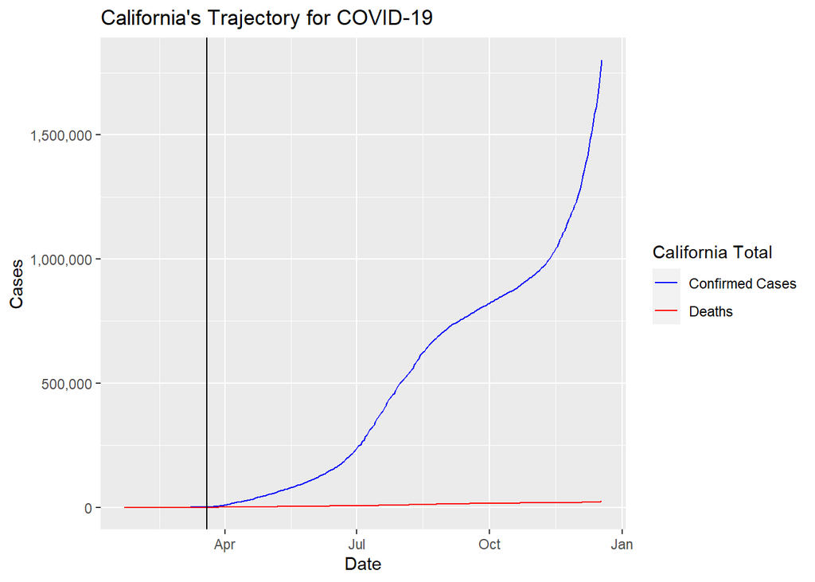

```r
obj4chart1colors <- c("Confirmed Cases" = "blue", "Deaths" = "red")

# these are two disparate time series glued together
ggplot() +
  geom_line(data = dfConfirmedCAChartData,
            aes(x = `Date`, y = `Confirmed Cases`,
            color = "Confirmed Cases")) +
  geom_line(data = dfDeathsCAChartData,
            aes(x = `Date`, y = `Deaths`,
            color = "Deaths")) +
  scale_y_continuous(labels = scales::comma) +
  labs(x = "Date", y = "Cases", color = "California Total") +
  ggtitle("California's Trajectory for COVID-19") +
  scale_color_manual(values = obj4chart1colors) +
  geom_vline(xintercept = as.numeric(as.Date("2020-03-19")),
             color = "black")
```

```r
# reuses earlier data frame for only CA confirmed cases by county
dfConfirmedCAChartData <- ConfirmedUS %>%

  # removes all columns with numeric values that aren't case counts
  select(-(`UID`)) %>%
  select(-(`code3`)) %>%
  select(-(`FIPS`)) %>%
  select(-(`Lat`)) %>%
  select(-(`Long_`)) %>%

  # retains only the California rows
  filter(`Province_State` == "California") %>%

  # retains only the rows for San Diego, Riverside, LA
  filter(`Admin2` %in%
           c("San Diego", "Riverside", "Los Angeles")) %>%

  # groups by County (aka Admin2)
  group_by(`Admin2`) %>%

  # totals all columns that are numeric
  summarise_if(is.numeric, sum) %>%

  # gathers data into long form
  gather(key=Date, value=`Confirmed Cases`, -`Admin2`) %>%

  # converts the date column into real dates for the chart
  mutate(`Date`=as.Date(`Date`, format = "%m/%d/%y"))
```

Below is a chart showing the confirmed cases over time, only for the counties of Los Angeles, Riverside, and San Diego. The black vertical line provides a visual representation of when the first shutdowns occurred on March 19, 2020.

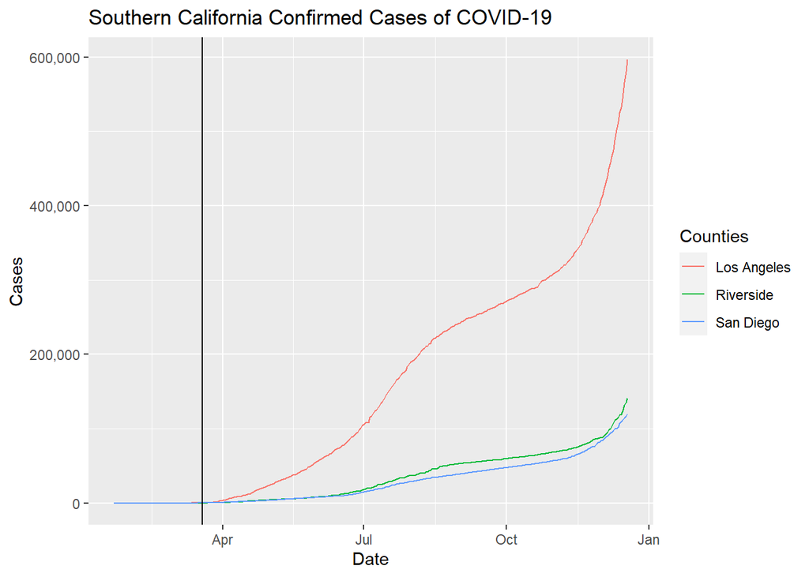

```r
ggplot(dfConfirmedCAChartData,
       aes(x = `Date`, y = `Confirmed Cases`,
           group = `Admin2`)) +
  geom_line(aes(color=`Admin2`)) +
  ggtitle("Southern California Confirmed Cases of COVID-19") +
  scale_y_continuous(labels = scales::comma) +
  labs(x = "Date", y = "Cases", color = "Counties") +
  geom_vline(xintercept = as.numeric(as.Date("2020-03-19")),
             color = "black")
```

# Objective 5 - Digging Deeper

```r
# creates new data frame for only the most recent day's deaths
dfDeathsUSLast <- DeathsUS %>%

  # select only the UID, Population, and last (most recent) columns
  select(c(`UID`, `Population`, tail(names(.),1))) %>%

  # renames last column to Deaths
  rename(Deaths = tail(names(.),1)) %>%

  # filters out rows with a population or death count of 0
  filter(`Population` > 0) %>%
  filter(`Deaths` > 0)

# creates new data frame for only the most recent day's confirmed cases
dfConfirmedUSLast <- ConfirmedUS %>%

  # select only the UID and last (most recent) columns
  select(c(`UID`, tail(names(.),1))) %>%

  # renames last column to Confirmed Cases
  rename("Confirmed Cases" = tail(names(.),1))

# combines two data frames by matching UID via inner join
dfCombinedUSLast <- dfDeathsUSLast %>%
  inner_join(dfConfirmedUSLast, by = "UID")

  ### we do not need to gather this data into long form
  # gathers data into long form
  # gather(key=Type, value=Count, -`UID`)
```

Below is a *cowplot* showing two side-by-side charts highlighting the relationship between Confirmed Cases versus total Population, and Deaths versus Confirmed Cases. Both plots have the axes log transformed in order to better accommodate the varying scales at larger and smaller values.

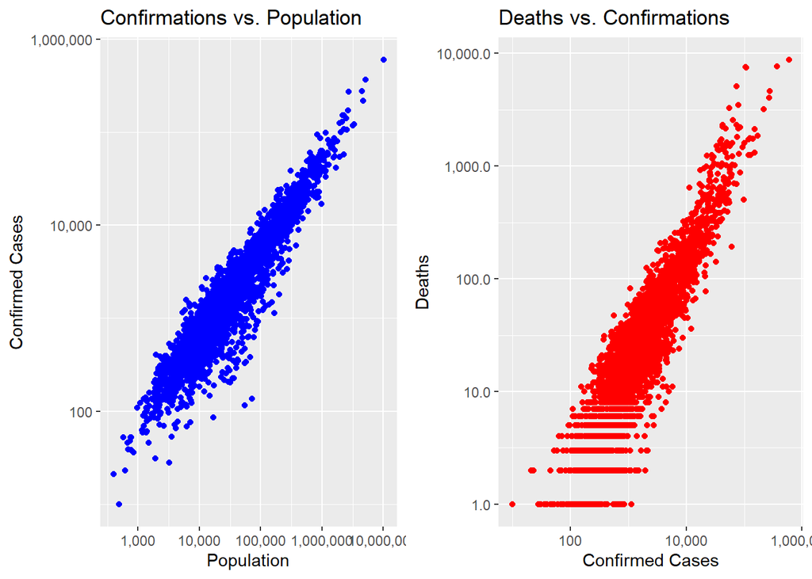

```r
# building the cowplot
p1 <- ggplot(dfCombinedUSLast,
       aes(`Population`, `Confirmed Cases`)) +
  geom_point(color = "blue") +
  ggtitle("Confirmations vs. Population") +
  scale_x_log10(labels = scales::comma) +
  scale_y_log10(labels = scales::comma)

p2 <- ggplot(dfCombinedUSLast,
       aes(`Confirmed Cases`, `Deaths`)) +
  geom_point(color = "red") +
  ggtitle("Deaths vs. Confirmations") +
  scale_x_log10(labels = scales::comma) +
  scale_y_log10(labels = scales::comma)

plot_grid(p1, p2)
```

The GitHub project page can be viewed at:

https://github.com/alexanderyu-palomar/CSIT165-Project2

(Git code posted on the Project assignment page is not knitting properly according to the instructions.)